# gapminder-wrangle

Qiyao Jiang

2025-06-28

# Ways to Analyze Long format data

## Step1: Prepare your package

We introduce package “tidyverse”, a strong package for data processing.

```r
library(tidyverse)
```

## Step2: Prepare your data

We read the data using readr::read_csv(“readr::” can be omitted if we have written “library(tidyverse)”), and use str(), names(), head(), tail() to have a first glimpse of our data. Here we use gapminder.csv for an example.

```r
gapminder <- readr::read_csv("data/gapminder.csv")
str(gapminder)
```

```
## spc_tbl_ [1,704 × 6] (S3: spec_tbl_df/tbl_df/tbl/data.frame)
##  $ country  : chr [1:1704] "Afghanistan" "Afghanistan" "Afghanistan" "Afghanistan" ...
##  $ year     : num [1:1704] 1952 1957 1962 1967 1972 ...
##  $ pop      : num [1:1704] 8425333 9240934 10267083 11537966 13079460 ...
##  $ continent: chr [1:1704] "Asia" "Asia" "Asia" "Asia" ...
##  $ lifeExp  : num [1:1704] 28.8 30.3 32 34 36.1 ...
##  $ gdpPercap: num [1:1704] 779 821 853 836 740 ...
##  - attr(*, "spec")=
##   .. cols(
##   ..   country = col_character(),
##   ..   year = col_double(),
##   ..   pop = col_double(),
##   ..   continent = col_character(),
##   ..   lifeExp = col_double(),
##   ..   gdpPercap = col_double()
##   .. )
##  - attr(*, "problems")=<externalptr>
```

```r
names(gapminder)
```

```
## [1] "country"   "year"      "pop"       "continent" "lifeExp"   "gdpPercap"
```

```r
head(gapminder, 5)
```

| country | year | pop | continent | lifeExp | gdpPercap |
| --- | --- | --- | --- | --- | --- |
| Afghanistan | 1952 | 8425333 | Asia | 28.801 | 779.4453 |
| Afghanistan | 1957 | 9240934 | Asia | 30.332 | 820.8530 |
| Afghanistan | 1962 | 10267083 | Asia | 31.997 | 853.1007 |
| Afghanistan | 1967 | 11537966 | Asia | 34.020 | 836.1971 |
| Afghanistan | 1972 | 13079460 | Asia | 36.088 | 739.9811 |

## Step3: Data processsing

### 1.filter(data=data, your_logical_expression(can have multiple expressions here), …)

This will select the rows that satisfy your conditions.

```r
filter(gapminder, lifeExp<29)
```

| country | year | pop | continent | lifeExp | gdpPercap |
| --- | --- | --- | --- | --- | --- |
| Afghanistan | 1952 | 8425333 | Asia | 28.801 | 779.4453 |
| Rwanda | 1992 | 7290203 | Africa | 23.599 | 737.0686 |

```r
filter(gapminder, country %in% c("China", "Japan"))
```

| country | year | pop | continent | lifeExp | gdpPercap |
| --- | --- | --- | --- | --- | --- |
| China | 1952 | 556263528 | Asia | 44.00000 | 400.4486 |
| China | 1957 | 637408000 | Asia | 50.54896 | 575.9870 |
| China | 1962 | 665770000 | Asia | 44.50136 | 487.6740 |
| China | 1967 | 754550000 | Asia | 58.38112 | 612.7057 |
| China | 1972 | 862030000 | Asia | 63.11888 | 676.9001 |
| China | 1977 | 943455000 | Asia | 63.96736 | 741.2375 |
| China | 1982 | 1000281000 | Asia | 65.52500 | 962.4214 |
| China | 1987 | 1084035000 | Asia | 67.27400 | 1378.9040 |
| China | 1992 | 1164970000 | Asia | 68.69000 | 1655.7842 |
| China | 1997 | 1230075000 | Asia | 70.42600 | 2289.2341 |

[output cut: 14 more lines]

### 2.group_by(), mutate(), summarize(), arrange() and pipe “|>”

For more information, please refer to slides “wrangling.pdf”, “grouping.pdf” & “Chapter4.pdf”.

```r
gapminder |>
  filter(year==2002) |>
  group_by(continent) |>
  mutate(count_pop = sum(pop))
```

| country | year | pop | continent | lifeExp | gdpPercap | count_pop |
| --- | --- | --- | --- | --- | --- | --- |
| Afghanistan | 2002 | 25268405 | Asia | 42.129 | 726.7341 | 3601802203 |
| Albania | 2002 | 3508512 | Europe | 75.651 | 4604.2117 | 578223869 |
| Algeria | 2002 | 31287142 | Africa | 70.994 | 5288.0404 | 833723916 |
| Angola | 2002 | 10866106 | Africa | 41.003 | 2773.2873 | 833723916 |
| Argentina | 2002 | 38331121 | Americas | 74.340 | 8797.6407 | 849772762 |
| Australia | 2002 | 19546792 | Oceania | 80.370 | 30687.7547 | 23454829 |
| Austria | 2002 | 8148312 | Europe | 78.980 | 32417.6077 | 578223869 |
| Bahrain | 2002 | 656397 | Asia | 74.795 | 23403.5593 | 3601802203 |
| Bangladesh | 2002 | 135656790 | Asia | 62.013 | 1136.3904 | 3601802203 |
| Belgium | 2002 | 10311970 | Europe | 78.320 | 30485.8838 | 578223869 |

[output cut: 132 more lines]

```r
gapminder |>
  group_by(continent, year) |>
  summarize(count_pop = sum(pop)) |>
  ungroup()
```

| continent | year | count_pop |
| --- | --- | --- |
| Africa | 1952 | 237640501 |
| Africa | 1957 | 264837738 |
| Africa | 1962 | 296516865 |
| Africa | 1967 | 335289489 |
| Africa | 1972 | 379879541 |
| Africa | 1977 | 433061021 |
| Africa | 1982 | 499348587 |
| Africa | 1987 | 574834110 |
| Africa | 1992 | 659081517 |
| Africa | 1997 | 743832984 |

[output cut: 50 more lines]

```r
gapminder |>
  group_by(continent, year) |>
  summarize(gdp = sum(gdpPercap*pop)) |>
  arrange(gdp, .by_group=FALSE)
```

| continent | year | gdp |
| --- | --- | --- |
| Oceania | 1952 | 1.083144e+11 |
| Oceania | 1957 | 1.336537e+11 |
| Oceania | 1962 | 1.646729e+11 |
| Oceania | 1967 | 2.119177e+11 |
| Oceania | 1972 | 2.682242e+11 |
| Oceania | 1977 | 3.094154e+11 |
| Africa | 1952 | 3.115993e+11 |
| Oceania | 1982 | 3.523543e+11 |
| Africa | 1957 | 3.826778e+11 |
| Oceania | 1987 | 4.189031e+11 |

[output cut: 50 more lines]

This is another example of the workflow. Notice that you have to read .tsv files with readr::read.**tsv**, NOT readr::read.**csv**!

```r
judgements <- readr::read_tsv("https://biostat2.uni.lu/practicals/data/judgments.tsv", show_col_types=FALSE)
glimpse(judgements)
```

```
## Rows: 188
## Columns: 158
## $ start_date                 <chr> "11/3/2014", "11/3/2014", "11/3/2014", "11/…
## $ end_date                   <chr> "11/3/2014", "11/3/2014", "11/3/2014", "11/…
## $ finished                   <dbl> 1, 1, 1, 1, 1, 1, 1, 1, 1, 1, 1, 1, 1, 1, 1…
## $ condition                  <chr> "control", "stress", "stress", "stress", "c…
## $ subject                    <dbl> 2, 1, 3, 4, 7, 6, 5, 9, 16, 13, 18, 14, 12,…
## $ gender                     <chr> "female", "female", "female", "female", "fe…
## $ age                        <dbl> 24, 19, 19, 22, 22, 22, 18, 20, 21, 19, 19,…
## $ mood_pre                   <dbl> 81, 59, 22, 53, 48, 73, NA, 100, 67, 30, 55…
## $ mood_post                  <dbl> NA, 42, 60, 68, NA, 73, NA, NA, 74, 68, 57,…
## $ STAI_pre_1_1               <dbl> 2, 3, 4, 2, 1, 2, 2, 1, 2, 4, 2, 1, 2, 1, 1…
## $ STAI_pre_1_2               <dbl> 1, 2, 3, 2, 1, 2, 2, 1, 2, 2, 3, 2, 2, 1, 1…
## $ STAI_pre_1_3               <dbl> 2, 3, 3, 2, 1, 1, 1, 1, 1, 3, 1, 2, 2, 2, 2…
## $ STAI_pre_1_4               <dbl> 2, 1, 3, 2, 1, 1, 1, 1, 1, 3, 1, 2, 1, 1, 1…
```

[output cut: 145 more lines]

```r
names(judgements)
```

```
##   [1] "start_date"                 "end_date"
##   [3] "finished"                   "condition"
##   [5] "subject"                    "gender"
##   [7] "age"                        "mood_pre"
##   [9] "mood_post"                  "STAI_pre_1_1"
##  [11] "STAI_pre_1_2"               "STAI_pre_1_3"
##  [13] "STAI_pre_1_4"               "STAI_pre_1_5"
##  [15] "STAI_pre_1_6"               "STAI_pre_1_7"
##  [17] "STAI_pre_2_1"               "STAI_pre_2_2"
##  [19] "STAI_pre_2_3"               "STAI_pre_2_4"
##  [21] "STAI_pre_2_5"               "STAI_pre_2_6"
##  [23] "STAI_pre_2_7"               "STAI_pre_3_1"
##  [25] "STAI_pre_3_2"               "STAI_pre_3_3"
##  [27] "STAI_pre_3_4"               "STAI_pre_3_5"
##  [29] "STAI_pre_3_6"               "STAI_post_1_1"
```

[output cut: 64 more lines]

```r
select(judgements, gender, age, condition) |>
  arrange(age)
```

| gender | age | condition |
| --- | --- | --- |
| female | 17 | stress |
| female | 17 | control |
| male | 17 | control |
| female | 17 | stress |
| female | 17 | stress |
| female | 17 | control |
| female | 17 | stress |
| female | 17 | stress |
| female | 18 | control |
| female | 18 | stress |

[output cut: 178 more lines]

```r
new_judgements <- judgements |>
  mutate(
    mood_change = mood_post - mood_pre,
    mood_change_norm = abs(mood_change / mean(mood_change, na.rm=TRUE))) |>
  relocate(starts_with("mood")) |>
  arrange(desc(mood_change_norm))
head(new_judgements)
```

| mood_pre | mood_post | mood_change | mood_change_norm | start_date | end_date | finished | condition | subject | gender | age | STAI_pre_1_1 | STAI_pre_1_2 | STAI_pre_1_3 | STAI_pre_1_4 | STAI_pre_1_5 | STAI_pre_1_6 | STAI_pre_1_7 | STAI_pre_2_1 | STAI_pre_2_2 | STAI_pre_2_3 | STAI_pre_2_4 | STAI_pre_2_5 | STAI_pre_2_6 | STAI_pre_2_7 | STAI_pre_3_1 | STAI_pre_3_2 | STAI_pre_3_3 | STAI_pre_3_4 | STAI_pre_3_5 | … |
| --- | --- | --- | --- | --- | --- | --- | --- | --- | --- | --- | --- | --- | --- | --- | --- | --- | --- | --- | --- | --- | --- | --- | --- | --- | --- | --- | --- | --- | --- | --- |
| 66 | 0 | -66 | 9.119658 | 11/3/2014 | 11/3/2014 | 1 | stress | 24 | female | 20 | 3 | 2 | 2 | 1 | 2 | 1 | 2 | 2 | 1 | 2 | 2 | 2 | 2 | 1 | 2 | 2 | 2 | 1 | 2 | … |
| 77 | 22 | -55 | 7.599715 | 11/4/2014 | 11/4/2014 | 1 | stress | 66 | female | 20 | 2 | 2 | 1 | 2 | 2 | 1 | 1 | 3 | 1 | 2 | 2 | 1 | 1 | 2 | 2 | 2 | 1 | 1 | 2 | … |
| 47 | 100 | 53 | 7.323362 | 11/5/2014 | 11/5/2014 | 1 | stress | 93 | female | 24 | 3 | 3 | 2 | 2 | 3 | 2 | 1 | 3 | 2 | 3 | 2 | 2 | 2 | 3 | 2 | 3 | 1 | 2 | 3 | … |
| 25 | 72 | 47 | 6.494302 | 11/4/2014 | 11/4/2014 | 1 | stress | 73 | female | 19 | 4 | 3 | 3 | 3 | 4 | 2 | 3 | 3 | 3 | 3 | 4 | 3 | 3 | 2 | 4 | 3 | 2 | 2 | 4 | … |
| 22 | 69 | 47 | 6.494302 | 11/5/2014 | 11/5/2014 | 1 | stress | 109 | female | 18 | 4 | 3 | 4 | 4 | 3 | 3 | 2 | 3 | 2 | 4 | 4 | 4 | 4 | 3 | 4 | 3 | 3 | 3 | 4 | … |
| 37 | 83 | 46 | 6.356125 | 11/6/2014 | 11/6/2014 | 1 | stress | 130 | female | 20 | 2 | 1 | 2 | 1 | 2 | 2 | 1 | 3 | 1 | 3 | 1 | 1 | 1 | 1 | 2 | 2 | 1 | 1 | 3 | … |

```r
mean(new_judgements$mood_change, na.rm=TRUE)
```

```
## [1] 7.237113
```

```r
co2 = read_csv("data/co2.csv")
head(co2, 10)
```

| country | co2_2007 |
| --- | --- |
| Afghanistan | 2937.88342 |
| Albania | 4217.55106 |
| Algeria | 105838.12850 |
| American Samoa | 18.36844 |
| Angola | 17405.00473 |
| Anguilla | 12.35392 |
| Argentina | 175532.77873 |
| Armenia | 5336.28877 |
| Aruba | 282.15189 |
| Australia | 425956.58877 |

```r
names(co2)
```

```
## [1] "country"  "co2_2007"
```

```r
gap_2007 <- gapminder |>
  filter(year==2007)
dim(gap_2007)
```

```
## [1] 142   6
```

```r
rj <- right_join(gap_2007, co2, by="country")
rj
```

| country | year | pop | continent | lifeExp | gdpPercap | co2_2007 |
| --- | --- | --- | --- | --- | --- | --- |
| Afghanistan | 2007 | 31889923 | Asia | 43.828 | 974.5803 | 2937.88342 |
| Albania | 2007 | 3600523 | Europe | 76.423 | 5937.0295 | 4217.55106 |
| Algeria | 2007 | 33333216 | Africa | 72.301 | 6223.3675 | 105838.12850 |
| Angola | 2007 | 12420476 | Africa | 42.731 | 4797.2313 | 17405.00473 |
| Argentina | 2007 | 40301927 | Americas | 75.320 | 12779.3796 | 175532.77873 |
| Australia | 2007 | 20434176 | Oceania | 81.235 | 34435.3674 | 425956.58877 |
| Austria | 2007 | 8199783 | Europe | 79.829 | 36126.4927 | 75961.44988 |
| American Samoa | NA | NA | NA | NA | NA | 18.36844 |
| Anguilla | NA | NA | NA | NA | NA | 12.35392 |
| Armenia | NA | NA | NA | NA | NA | 5336.28877 |

[output cut: 2 more lines]

# Before Data Processing: CLEAN Your Data

This is a terrible wide format data:

```r
gap_wide <- read_csv("data/gapminder_wide.csv")
head(gap_wide)
```

| continent | country | gdpPercap_1952 | gdpPercap_1957 | gdpPercap_1962 | gdpPercap_1967 | gdpPercap_1972 | gdpPercap_1977 | gdpPercap_1982 | gdpPercap_1987 | gdpPercap_1992 | gdpPercap_1997 | gdpPercap_2002 | gdpPercap_2007 | lifeExp_1952 | lifeExp_1957 | lifeExp_1962 | lifeExp_1967 | lifeExp_1972 | lifeExp_1977 | lifeExp_1982 | lifeExp_1987 | lifeExp_1992 | lifeExp_1997 | lifeExp_2002 | lifeExp_2007 | pop_1952 | pop_1957 | pop_1962 | pop_1967 | … |
| --- | --- | --- | --- | --- | --- | --- | --- | --- | --- | --- | --- | --- | --- | --- | --- | --- | --- | --- | --- | --- | --- | --- | --- | --- | --- | --- | --- | --- | --- | --- |
| Africa | Algeria | 2449.0082 | 3013.9760 | 2550.8169 | 3246.9918 | 4182.6638 | 4910.4168 | 5745.1602 | 5681.3585 | 5023.2166 | 4797.2951 | 5288.0404 | 6223.3675 | 43.077 | 45.685 | 48.303 | 51.407 | 54.518 | 58.014 | 61.368 | 65.799 | 67.744 | 69.152 | 70.994 | 72.301 | 9279525 | 10270856 | 11000948 | 12760499 | … |
| Africa | Angola | 3520.6103 | 3827.9405 | 4269.2767 | 5522.7764 | 5473.2880 | 3008.6474 | 2756.9537 | 2430.2083 | 2627.8457 | 2277.1409 | 2773.2873 | 4797.2313 | 30.015 | 31.999 | 34.000 | 35.985 | 37.928 | 39.483 | 39.942 | 39.906 | 40.647 | 40.963 | 41.003 | 42.731 | 4232095 | 4561361 | 4826015 | 5247469 | … |
| Africa | Benin | 1062.7522 | 959.6011 | 949.4991 | 1035.8314 | 1085.7969 | 1029.1613 | 1277.8976 | 1225.8560 | 1191.2077 | 1232.9753 | 1372.8779 | 1441.2849 | 38.223 | 40.358 | 42.618 | 44.885 | 47.014 | 49.190 | 50.904 | 52.337 | 53.919 | 54.777 | 54.406 | 56.728 | 1738315 | 1925173 | 2151895 | 2427334 | … |
| Africa | Botswana | 851.2411 | 918.2325 | 983.6540 | 1214.7093 | 2263.6111 | 3214.8578 | 4551.1421 | 6205.8839 | 7954.1116 | 8647.1423 | 11003.6051 | 12569.8518 | 47.622 | 49.618 | 51.520 | 53.298 | 56.024 | 59.319 | 61.484 | 63.622 | 62.745 | 52.556 | 46.634 | 50.728 | 442308 | 474639 | 512764 | 553541 | … |
| Africa | Burkina Faso | 543.2552 | 617.1835 | 722.5120 | 794.8266 | 854.7360 | 743.3870 | 807.1986 | 912.0631 | 931.7528 | 946.2950 | 1037.6452 | 1217.0330 | 31.975 | 34.906 | 37.814 | 40.697 | 43.591 | 46.137 | 48.122 | 49.557 | 50.260 | 50.324 | 50.650 | 52.295 | 4469979 | 4713416 | 4919632 | 5127935 | … |
| Africa | Burundi | 339.2965 | 379.5646 | 355.2032 | 412.9775 | 464.0995 | 556.1033 | 559.6032 | 621.8188 | 631.6999 | 463.1151 | 446.4035 | 430.0707 | 39.031 | 40.533 | 42.045 | 43.548 | 44.057 | 45.910 | 47.471 | 48.211 | 44.736 | 45.326 | 47.360 | 49.580 | 2445618 | 2667518 | 2961915 | 3330989 | … |

We can use pivot_longer()(and pivot_wider() if we like) to transfer it into long format nice and neatly:

```r
gap_long <- gap_wide |>
  pivot_longer(
    cols = -c("continent", "country"),
    names_to = c("Variable","Year"),
    names_sep = "_",
    values_to = "Value"
  )  |>
  pivot_wider(
    names_from = Variable,
    values_from = Value
  ) |>
  mutate(
    Year = as.numeric(Year),
    GDP = pop*gdpPercap
  )
head(gap_long)
```

| continent | country | Year | gdpPercap | lifeExp | pop | GDP |
| --- | --- | --- | --- | --- | --- | --- |
| Africa | Algeria | 1952 | 2449.008 | 43.077 | 9279525 | 22725632678 |
| Africa | Algeria | 1957 | 3013.976 | 45.685 | 10270856 | 30956113720 |
| Africa | Algeria | 1962 | 2550.817 | 48.303 | 11000948 | 28061403854 |
| Africa | Algeria | 1967 | 3246.992 | 51.407 | 12760499 | 41433235247 |
| Africa | Algeria | 1972 | 4182.664 | 54.518 | 14760787 | 61739408943 |
| Africa | Algeria | 1977 | 4910.417 | 58.014 | 17152804 | 84227416174 |

```r
tail(gap_long)
```

| continent | country | Year | gdpPercap | lifeExp | pop | GDP |
| --- | --- | --- | --- | --- | --- | --- |
| Oceania | New Zealand | 1982 | 17632.41 | 73.840 | 3210650 | 56611498451 |
| Oceania | New Zealand | 1987 | 19007.19 | 74.320 | 3317166 | 63050008703 |
| Oceania | New Zealand | 1992 | 18363.32 | 76.330 | 3437674 | 63127124700 |
| Oceania | New Zealand | 1997 | 21050.41 | 77.550 | 3676187 | 77385257446 |
| Oceania | New Zealand | 2002 | 23189.80 | 79.110 | 3908037 | 90626601698 |
| Oceania | New Zealand | 2007 | 25185.01 | 80.204 | 4115771 | 103655730130 |

```r
str(gap_long)
```

```
## tibble [1,704 × 7] (S3: tbl_df/tbl/data.frame)
##  $ continent: chr [1:1704] "Africa" "Africa" "Africa" "Africa" ...
##  $ country  : chr [1:1704] "Algeria" "Algeria" "Algeria" "Algeria" ...
##  $ Year     : num [1:1704] 1952 1957 1962 1967 1972 ...
##  $ gdpPercap: num [1:1704] 2449 3014 2551 3247 4183 ...
##  $ lifeExp  : num [1:1704] 43.1 45.7 48.3 51.4 54.5 ...
##  $ pop      : num [1:1704] 9279525 10270856 11000948 12760499 14760787 ...
##  $ GDP      : num [1:1704] 2.27e+10 3.10e+10 2.81e+10 4.14e+10 6.17e+10 ...
```

Then, we can plot our data! Remember what we have done in the last session about ggplot2?

```r
China_verses_Japan_and_America_df <- gap_long |>
  filter(country %in% c("China", "Japan", "United States"))
China_verses_Japan_and_America_df
```

| continent | country | Year | gdpPercap | lifeExp | pop | GDP |
| --- | --- | --- | --- | --- | --- | --- |
| Americas | United States | 1952 | 13990.4821 | 68.44000 | 157553000 | 2.204242e+12 |
| Americas | United States | 1957 | 14847.1271 | 69.49000 | 171984000 | 2.553468e+12 |
| Americas | United States | 1962 | 16173.1459 | 70.21000 | 186538000 | 3.016906e+12 |
| Americas | United States | 1967 | 19530.3656 | 70.76000 | 198712000 | 3.880918e+12 |
| Americas | United States | 1972 | 21806.0359 | 71.34000 | 209896000 | 4.577000e+12 |
| Americas | United States | 1977 | 24072.6321 | 73.38000 | 220239000 | 5.301732e+12 |
| Americas | United States | 1982 | 25009.5591 | 74.65000 | 232187835 | 5.806915e+12 |
| Americas | United States | 1987 | 29884.3504 | 75.02000 | 242803533 | 7.256026e+12 |
| Americas | United States | 1992 | 32003.9322 | 76.09000 | 256894189 | 8.221624e+12 |
| Americas | United States | 1997 | 35767.4330 | 76.81000 | 272911760 | 9.761353e+12 |

[output cut: 26 more lines]

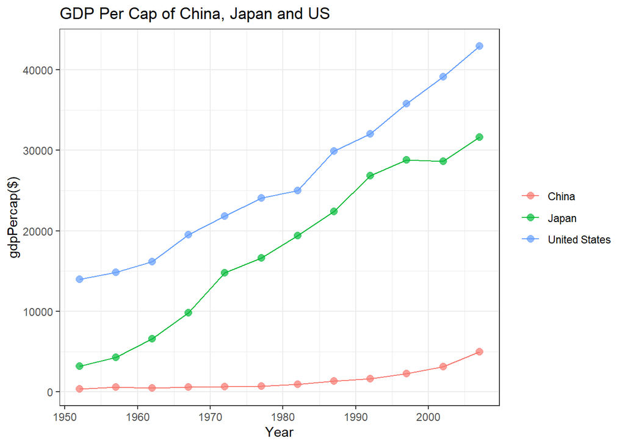

```r
ggplot(China_verses_Japan_and_America_df) +
  geom_point(aes(x=Year, y=gdpPercap, color=country), alpha=0.7, size=2.5) +
  geom_line(aes(x=Year, y=gdpPercap, color=country)) +
  labs(x="Year", y="gdpPercap($)", title="GDP Per Cap of China, Japan and US") +
  theme_bw() +
  theme(legend.title = element_blank())
```

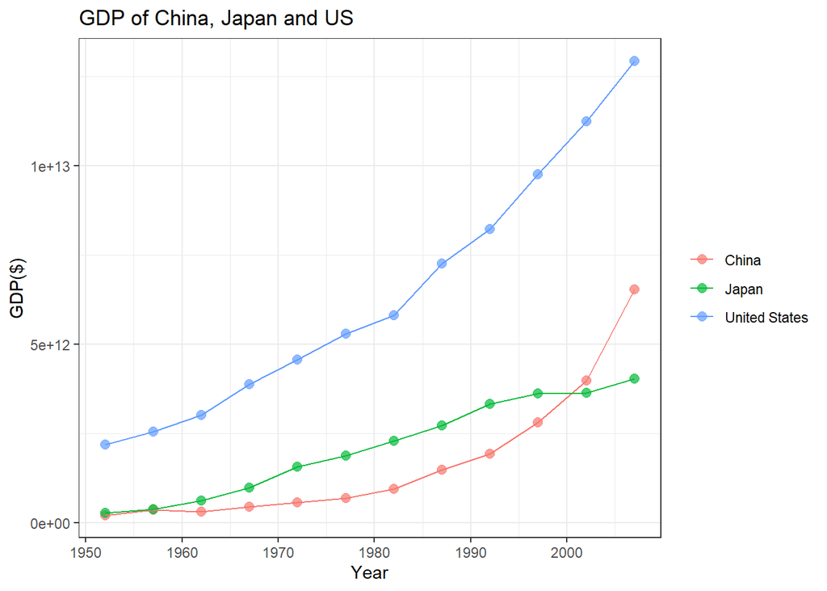

```r
ggplot(China_verses_Japan_and_America_df) +
  geom_point(aes(x=Year, y=GDP, color=country), alpha=0.7, size=2.5) +
  geom_line(aes(x=Year, y=GDP, color=country)) +
  labs(x="Year", y="GDP($)", title="GDP of China, Japan and US") +
  theme_bw() +
  theme(legend.title = element_blank())
```